# Exame Take Home - Econometria 2

TomasGarcia

2025-07-04

Tomás Polido Garcia NUSP: 10693952

**Parte 1 - Compreensão da Pesquisa 1. Questão de Pesquisa e Alegação Causal: Em suas próprias palavras, declare claramente a principal questão de pesquisa que os autores estão tentando responder. Qual é a principal relação causal que eles visam identificar? Explique o argumento central do artigo sobre instituições, história colonial e desenvolvimento econômico.**

A principal questão de pesquisa que os autores estão tentando responder é como estimar os efeitos de instituições na performance econômica dos países (isto é, a relação causal do nível das instituições na renda per capita dos países). O argumento central do artigo é que os países europeus adotaram instituições coloniais muito distintas dependendo da taxa de mortalidade das colônias (onde não era possível se estabelecer, faziam-se instituições extrativistas). Essas instituições coloniais moldaram as instituições modernas que por sua vez afetam o desenvolvimento econômico atual dos países.

**2. A Estratégia de Identificação:**

**(a) Explique por que uma regressão de Mínimos Quadrados Ordinários (MQO) simples do desempenho econômico atual de um país (por exemplo, log do PIB per capita) em uma medida de sua qualidade institucional atual provavelmente produzirá estimativas viesadas. Discuta pelo menos duas fontes de endogeneidade neste contexto.**

Uma regressão de MQO simples entre desempenho econômico atual e sua qualidade institucional provavelmente produzirá estimativas viesadas por diversos motivos: 1) pode ocorrer causalidade reversa; pode ser que países ricos prefiram instituições melhores, e não que as instituições façam eles serem mais ricos 2) pode ser que a mensuração das instituições, que foi feita ex post, seja viesada pelos criadores dos rankings institucionais (analistas têm um viés natural de enxergar instituições melhores em países mais ricos) 3) Por último, podem haver determinantes omitidas que vão ser naturalmente correlacionadas com instituições. Esses são fatores de possíveis endogeneidades positivas, mas também podem haver endogeneidades negativas, tais como: a variável de instituição é mensurada com erro considerável e não corresponde exatamente ao cluster de instituições que interessam na prática.

**(b) Descreva a variável instrumental que os autores utilizam: mortalidade de colonos.**

Em primeiro lugar, os autores utilizam a mortalidade de colonos como variável instrumental porque há toda uma literatura histórica dos fatores que levaram a diferentes tipos de colonização por parte dos países europeus. Além disso, a teoria dos autores é de que a mortalidade potencial levou a estabelecimento/extrativismo, que por sua vez levou a instituições antigas, para instituições modernas, e finalmente para a performance econômica atual dos países.

**(c) Explique a lógica econômica por trás do instrumento. Por que a mortalidade de colonos deveria ser um instrumento relevante (ou seja, correlacionada com a variável endógena)? Por que deveria satisfazer a restrição de exclusão (ou seja, ser não correlacionada com a variável de resultado, exceto através de seu efeito nas instituições)?**

A lógica econômica do uso desse instrumento é que, condicional aos controles incluídos na regressão, as taxas de mortalidade de colonos europeus a mais de 100 anos não deveriam ter efeito no PIB per capita hoje, a não ser via instituições. Ela deve satisfazer a restrição de exclusão (não sendo correlacionada com a variável de resultado) porque provavelmente a mortalidade naquela época não tem a ver com o ambiente de doenças atual. A maior parte de mortes na época eram decorrentes de febre amarela e malária, que matavam muitos colonos, mas não a população local, que têm imunidade a elas (e portanto, dificilmente essas doenças explicam riqueza ou pobreza de países atualmente). Portanto, o efeito da mortalidade da época afetou instituições que, por sua vez, afetaram o desenvolvimento econômico atual.

**Parte 2 - Replicação**

**Esta seção é o cerne do exercício de replicação. Seu objetivo é reproduzir os principais resultados do artigo o mais próximo possível.**

**3. Estatísticas Descritivas: Replique a Tabela 1 do artigo. Esta tabela fornece estatísticas descritivas para as variáveis principais. Apresente sua tabela replicada ao lado da original. Discuta quaisquer pequenas discrepâncias e razões potenciais para elas (por exemplo, pequenas diferenças nos dados disponíveis publicamente versus os usados em 2001).**

```r
library(haven)
library(dplyr)
library(tidyr)
library(kableExtra)
```

```r
# 1. Função de sumário
safe_summary <- function(x, invert = FALSE) {
  if (all(is.na(x))) return(data.frame(mean = NA, sd = NA, n = 0))
  if (invert) x <- -x
  data.frame(
    mean = mean(x, na.rm = TRUE),
    sd = sd(x, na.rm = TRUE),
    n = sum(!is.na(x))
  )
}

# 2. Carregar e preparar os dados
data <- read_dta("maketable1.dta") %>%
  mutate(
    q = case_when(
      extmort4 <= 50 ~ 1,
      extmort4 <= 80 ~ 2,
      extmort4 <= 150 ~ 3,
      extmort4 > 150 ~ 4,
      TRUE ~ NA_real_
    ),
    loghjypl = -loghjypl
  )

# 3. Definir números de observações
obs_counts <- c("Whole world" = 163, "Base sample" = 64,
               "1" = 14, "2" = 18, "3" = 17, "4" = 15)

# 4. Função para calcular estatísticas por grupo
calculate_group_stats <- function(df, group_name) {
  vars <- c("logpgp95", "loghjypl", "avexpr", "cons00a",
           "cons1", "democ00a", "euro1900")

  if (group_name != "Whole world") {
    vars <- c(vars, "logem4")
  }

  result <- data.frame()
  for (v in vars) {
    if (v == "logem4" && group_name == "Whole world") {
      res <- data.frame(var = v, mean = NA, sd = NA, n = NA)
    } else {
      invert <- ifelse(v == "loghjypl", TRUE, FALSE)
      stats <- safe_summary(df[[v]], invert = invert)
      res <- cbind(data.frame(var = v), stats)
    }
    result <- rbind(result, res)
  }

  result$group <- group_name
  return(result)
}

# 5. Calcular estatísticas para todos os grupos
groups <- list(
  list(data = data, name = "Whole world"),
  list(data = filter(data, baseco == 1), name = "Base sample"),
  list(data = filter(data, q == 1), name = "1"),
  list(data = filter(data, q == 2), name = "2"),
  list(data = filter(data, q == 3), name = "3"),
  list(data = filter(data, q == 4), name = "4")
)

all_stats <- lapply(groups, function(g) {
  calculate_group_stats(g$data, g$name)
})

# 6. Combinar e formatar os resultados
final_data <- do.call(rbind, all_stats) %>%
  mutate(
    value = case_when(
      is.na(mean) ~ "n.a.",
      is.na(sd) ~ sprintf("%.2f", mean),
      TRUE ~ sprintf("%.2f (%.1f)", mean, sd)
    ),
    n = obs_counts[group]
  ) %>%
  select(var, group, value)

# Transformar para formato wide
final_table <- final_data %>%
  pivot_wider(names_from = group, values_from = value) %>%
  mutate(
    variable_label = case_when(
      var == "logpgp95" ~ "Log GDP per capita (PPP) in 1995",
      var == "loghjypl" ~ "Log output per worker in 1988 (with level of United States normalized to 1)",
      var == "avexpr" ~ "Average protection against expropriation risk, 1985-1995",
      var == "cons00a" ~ "Constraint on executive in 1900",
      var == "cons1" ~ "Constraint on executive in first year of independence",
      var == "democ00a" ~ "Democracy in 1900",
      var == "euro1900" ~ "European settlements in 1900",
      var == "logem4" ~ "Log European settler mortality",
      TRUE ~ var
    )
  ) %>%
  select(variable_label, everything(), -var)

# Adicionar linha de observações
obs_row <- data.frame(
  variable_label = "Number of observations",
  "Whole world" = "163",
  "Base sample" = "64",
  "1" = "14", "2" = "18", "3" = "17", "4" = "15",
  check.names = FALSE
)

final_table <- rbind(final_table, obs_row)

# 7. Formatar a tabela final
kable(final_table, align = c("l", rep("r", 6)),
      caption = "TABLE 1—DESCRIPTIVE STATISTICS",
      col.names = c("", "Whole world", "Base sample", "1", "2", "3", "4")) %>%
  kable_styling(bootstrap_options = c("striped", "hover"), full_width = FALSE) %>%
  add_header_above(c(" ", " ", " ", "By quartiles of mortality" = 4)) %>%
  column_spec(1, width = "5cm") %>%
  row_spec(nrow(final_table)-1, extra_css = "border-bottom: 1px solid #000000;")
```

TABLE 1—DESCRIPTIVE STATISTICS

|  | Whole world | Base sample | By quartiles of mortality 1 | By quartiles of mortality 2 | By quartiles of mortality 3 | By quartiles of mortality 4 |
| --- | --- | --- | --- | --- | --- | --- |
| Log GDP per capita (PPP) in 1995 | 8.30 (1.1) | 8.06 (1.0) | 8.95 (1.2) | 8.39 (0.6) | 8.01 (1.0) | 7.29 (0.7) |
| Log output per worker in 1988 (with level of United States normalized to 1) | -1.73 (1.1) | -1.93 (1.0) | -1.10 (1.0) | -1.46 (0.4) | -2.07 (0.9) | -2.91 (0.6) |
| Average protection against expropriation risk, 1985-1995 | 7.07 (1.8) | 6.52 (1.5) | 7.89 (1.8) | 6.50 (0.9) | 6.59 (1.5) | 5.70 (1.4) |
| Constraint on executive in 1900 | 1.86 (1.8) | 2.25 (2.1) | 3.13 (2.9) | 2.95 (2.1) | 1.18 (0.6) | 1.10 (0.5) |
| Constraint on executive in first year of independence | 3.59 (2.4) | 3.40 (2.4) | 5.86 (2.3) | 2.29 (1.8) | 4.00 (2.5) | 3.24 (2.1) |
| Democracy in 1900 | 1.15 (2.6) | 1.64 (3.0) | 3.36 (4.4) | 2.40 (2.8) | 0.20 (0.4) | 0.07 (0.3) |
| European settlements in 1900 | 30.47 (42.4) | 16.18 (25.5) | 34.19 (45.5) | 22.71 (18.2) | 6.46 (12.3) | 2.45 (6.2) |
| Log European settler mortality | NA | 4.66 (1.3) | 2.81 (0.8) | 4.28 (0.1) | 4.80 (0.3) | 5.87 (0.7) |
| Number of observations | 163 | 64 | 14 | 18 | 17 | 15 |

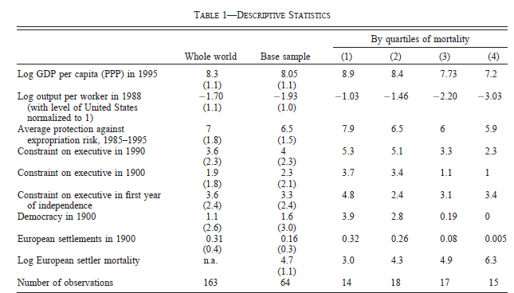

Imagem original

**4. Resultados Principais: Replique os resultados chave apresentados na Tabela 4 do artigo. Esta tabela é crucial, pois mostra os resultados de MQO e as principais estimativas de 2SLS (Mínimos Quadrados em Dois Estágios).**

**(a) Apresente sua tabela replicada. Para cada coeficiente, reporte a estimativa pontual e o erro padrão.** **(b) Rotule claramente quais partes do seu código produzem quais colunas da tabela.** **(c) Seus resultados se alinham com os do artigo publicado em termos de sinal, magnitude e significância estatística?**

```r
library(haven)
library(dplyr)
library(estimatr)
library(stargazer)
```

```r
# Carregar os dados
data <- read_dta("maketable4.dta") %>%
  filter(baseco == 1) %>%
  mutate(
    other_cont = case_when(
      shortnam %in% c("AUS", "MLT", "NZL") ~ 1,
      TRUE ~ 0
    )
  )

##################################################
### Panel A: Two-Stage Least Squares (2SLS) ###
##################################################

# Colunas 1-2: Base Sample
iv1 <- iv_robust(logpgp95 ~ avexpr | logem4, data = data)
iv2 <- iv_robust(logpgp95 ~ avexpr + lat_abst | logem4 + lat_abst, data = data)

# Colunas 3-4: Base Sample w/o Neo-Europes
iv3 <- iv_robust(logpgp95 ~ avexpr | logem4, data = filter(data, rich4 != 1))
iv4 <- iv_robust(logpgp95 ~ avexpr + lat_abst | logem4 + lat_abst, data = filter(data, rich4 != 1))

# Colunas 5-6: Base Sample w/o Africa
iv5 <- iv_robust(logpgp95 ~ avexpr | logem4, data = filter(data, africa != 1))
iv6 <- iv_robust(logpgp95 ~ avexpr + lat_abst | logem4 + lat_abst, data = filter(data, africa != 1))

# Colunas 7-8: Base Sample with continent dummies
iv7 <- iv_robust(logpgp95 ~ avexpr + africa + asia + other_cont |
                 logem4 + africa + asia + other_cont, data = data)
iv8 <- iv_robust(logpgp95 ~ avexpr + lat_abst + africa + asia + other_cont |
                 logem4 + lat_abst + africa + asia + other_cont, data = data)

# Coluna 9: Log GDP per worker
iv9 <- iv_robust(loghjypl ~ avexpr | logem4, data = data)

##################################################
### Panel B: First Stage Regressions ###
##################################################

# Primeiro estágio para as colunas 1-2
fs1 <- lm_robust(avexpr ~ logem4, data = data)
fs2 <- lm_robust(avexpr ~ logem4 + lat_abst, data = data)

# Primeiro estágio para as colunas 3-4
fs3 <- lm_robust(avexpr ~ logem4, data = filter(data, rich4 != 1))
fs4 <- lm_robust(avexpr ~ logem4 + lat_abst, data = filter(data, rich4 != 1))

# Primeiro estágio para as colunas 5-6
fs5 <- lm_robust(avexpr ~ logem4, data = filter(data, africa != 1))
fs6 <- lm_robust(avexpr ~ logem4 + lat_abst, data = filter(data, africa != 1))

# Primeiro estágio para as colunas 7-8
fs7 <- lm_robust(avexpr ~ logem4 + africa + asia + other_cont, data = data)
fs8 <- lm_robust(avexpr ~ logem4 + lat_abst + africa + asia + other_cont, data = data)

# Primeiro estágio para a coluna 9
fs9 <- lm_robust(avexpr ~ logem4, data = data)

##################################################
### Panel C: Ordinary Least Squares (OLS) ###
##################################################

# Colunas 1-2: Base Sample
ols1 <- lm_robust(logpgp95 ~ avexpr, data = data)
ols2 <- lm_robust(logpgp95 ~ avexpr + lat_abst, data = data)

# Colunas 3-4: Base Sample w/o Neo-Europes
ols3 <- lm_robust(logpgp95 ~ avexpr, data = filter(data, rich4 != 1))
ols4 <- lm_robust(logpgp95 ~ avexpr + lat_abst, data = filter(data, rich4 != 1))

# Colunas 5-6: Base Sample w/o Africa
ols5 <- lm_robust(logpgp95 ~ avexpr, data = filter(data, africa != 1))
ols6 <- lm_robust(logpgp95 ~ avexpr + lat_abst, data = filter(data, africa != 1))

# Colunas 7-8: Base Sample with continent dummies
ols7 <- lm_robust(logpgp95 ~ avexpr + africa + asia + other_cont, data = data)
ols8 <- lm_robust(logpgp95 ~ avexpr + lat_abst + africa + asia + other_cont, data = data)

# Coluna 9: Log GDP per worker
ols9 <- lm_robust(loghjypl ~ avexpr, data = data)
```

```r
library(modelsummary)
library(broom)

# Criação das listas por painel
iv_models <- list(
  "(1)" = iv1, "(2)" = iv2, "(3)" = iv3, "(4)" = iv4,
  "(5)" = iv5, "(6)" = iv6, "(7)" = iv7, "(8)" = iv8, "(9)" = iv9
)

fs_models <- list(
  "(1)" = fs1, "(2)" = fs2, "(3)" = fs3, "(4)" = fs4,
  "(5)" = fs5, "(6)" = fs6, "(7)" = fs7, "(8)" = fs8, "(9)" = fs9
)

ols_models <- list(
  "(1)" = ols1, "(2)" = ols2, "(3)" = ols3, "(4)" = ols4,
  "(5)" = ols5, "(6)" = ols6, "(7)" = ols7, "(8)" = ols8, "(9)" = ols9
)

# Nomes padronizados das variáveis
coef_names <- c(
  "avexpr" = "Average protection against\nexpropriation risk 1985–1995",
  "lat_abst" = "Latitude",
  "asia" = "Asia dummy",
  "africa" = "Africa dummy",
  "other_cont" = "\"Other\" continent dummy",
  "logem4" = "Log European settler mortality"
)

# Função para padronizar formatação
fmt_table <- function(models, title) {
  modelsummary(
    models,
    coef_map = c(
      "avexpr" = "Average protection against\nexpropriation risk 1985–1995",
      "lat_abst" = "Latitude",
      "asia" = "Asia dummy",
      "africa" = "Africa dummy",
      "other_cont" = "\"Other\" continent dummy",
      "logem4" = "Log European settler mortality"
    ),
    gof_omit = "IC|Log|Adj|F|RMSE",
    fmt = 2,
    stars = FALSE,
    title = title,
    notes = "Robust standard errors in parentheses."
  )
}
```

```r
fmt_table(iv_models,"Panel A: Two-Stage Least Squares")
```

|  | (1) | (2) | (3) | (4) | (5) | (6) | (7) | (8) | (9) |
| --- | --- | --- | --- | --- | --- | --- | --- | --- | --- |
| Average protection against expropriation risk 1985–1995 | 0.94 | 1.00 | 1.28 | 1.21 | 0.58 | 0.58 | 0.98 | 1.11 | 0.98 |
|  | (0.18) | (0.25) | (0.42) | (0.41) | (0.09) | (0.10) | (0.35) | (0.54) | (0.20) |
| Latitude |  | -0.65 |  | 0.94 |  | 0.04 |  | -1.18 |  |
|  |  | (1.30) |  | (1.24) |  | (0.54) |  | (1.93) |  |
| Asia dummy |  |  |  |  |  |  | -0.92 | -1.05 |  |
|  |  |  |  |  |  |  | (0.39) | (0.54) |  |
| Africa dummy |  |  |  |  |  |  | -0.46 | -0.44 |  |
|  |  |  |  |  |  |  | (0.33) | (0.40) |  |
| "Other" continent dummy |  |  |  |  |  |  | -0.94 | -0.99 |  |
|  |  |  |  |  |  |  | (1.02) | (1.20) |  |
| Num.Obs. | 64 | 64 | 60 | 60 | 37 | 37 | 64 | 64 | 61 |
| R2 | 0.187 | 0.102 | -0.688 | -0.492 | 0.587 | 0.589 | 0.229 | 0.011 | -0.152 |

Robust standard errors in parentheses.

```r
fmt_table(fs_models, "Panel B: First Stage for Average Protection Against Expropriation Risk in 1985–1995")
```

|  | (1) | (2) | (3) | (4) | (5) | (6) | (7) | (8) | (9) |
| --- | --- | --- | --- | --- | --- | --- | --- | --- | --- |
| Latitude |  | 2.00 |  | -0.11 |  | 0.99 |  | 2.01 |  |
|  |  | (1.42) |  | (1.45) |  | (1.34) |  | (1.56) |  |
| Asia dummy |  |  |  |  |  |  | 0.33 | 0.47 |  |
|  |  |  |  |  |  |  | (0.49) | (0.53) |  |
| Africa dummy |  |  |  |  |  |  | -0.27 | -0.26 |  |
|  |  |  |  |  |  |  | (0.35) | (0.34) |  |
| "Other" continent dummy |  |  |  |  |  |  | 1.24 | 1.06 |  |
|  |  |  |  |  |  |  | (0.86) | (0.87) |  |
| Log European settler mortality | -0.61 | -0.51 | -0.39 | -0.39 | -1.21 | -1.14 | -0.43 | -0.34 | -0.61 |
|  | (0.15) | (0.17) | (0.15) | (0.17) | (0.20) | (0.22) | (0.19) | (0.20) | (0.15) |
| Num.Obs. | 64 | 64 | 60 | 60 | 37 | 37 | 64 | 64 | 64 |
| R2 | 0.270 | 0.296 | 0.130 | 0.130 | 0.466 | 0.473 | 0.304 | 0.328 | 0.270 |

Robust standard errors in parentheses.

```r
fmt_table(ols_models, "Panel C: Ordinary Least Squares")
```

|  | (1) | (2) | (3) | (4) | (5) | (6) | (7) | (8) | (9) |
| --- | --- | --- | --- | --- | --- | --- | --- | --- | --- |
| Average protection against expropriation risk 1985–1995 | 0.52 | 0.47 | 0.49 | 0.47 | 0.48 | 0.47 | 0.42 | 0.40 | 0.46 |
|  | (0.05) | (0.06) | (0.07) | (0.08) | (0.05) | (0.07) | (0.06) | (0.07) | (0.05) |
| Latitude |  | 1.58 |  | 1.80 |  | 0.46 |  | 0.88 |  |
|  |  | (0.66) |  | (0.78) |  | (0.60) |  | (0.63) |  |
| Asia dummy |  |  |  |  |  |  | -0.63 | -0.58 |  |
|  |  |  |  |  |  |  | (0.28) | (0.31) |  |
| Africa dummy |  |  |  |  |  |  | -0.92 | -0.88 |  |
|  |  |  |  |  |  |  | (0.16) | (0.15) |  |
| "Other" continent dummy |  |  |  |  |  |  | 0.22 | 0.11 |  |
|  |  |  |  |  |  |  | (0.25) | (0.25) |  |
| Num.Obs. | 64 | 64 | 60 | 60 | 37 | 37 | 64 | 64 | 61 |
| R2 | 0.540 | 0.574 | 0.414 | 0.456 | 0.611 | 0.616 | 0.704 | 0.714 | 0.486 |

Robust standard errors in parentheses.

Podemos perceber que os dados batem com a Tabela 4 do paper de Acemoglu e Robinson, tanto em sinal, ordem de magnitude e significância estatística.

**Parte 3: Análise Crítica e Extensão**

**Nesta seção, você irá além da replicação pura para interpretar os achados e explorar a robustez dos resultados. A replicação bem-sucedida muitas vezes envolve questionar, não apenas confirmar, a análise original.**

**5. Interpretação e Robustez:**

**(b) Os autores realizam inúmeros testes de robustez. Descreva um desses testes (por exemplo, controlando por dummies de continente, ou usando medidas alternativas de instituições). Explique seu propósito e resuma os achados dos autores**

Um dos testes de robustez que os autores utilizam é o de controlar a regressão por “cultura europeia”, pois uma possível preocupação seria se o estudo está capturando o efeito de ter mais europeus na colônia estar relacionado a maior desenvolvimento. Para isso, os autores adicionam a porcentagem de população europeia, nas colunas 3 e 4 da tabela 6 do artigo, e têm como resultado que a variável é insignificante, enquanto os efeitos das instituições continua altamente signifcante, com coeficiente de 0.96 e erro padrão de 0.28.

**6. Extensão (Escolha uma): Proponha e execute uma extensão simples para a análise original. Seu objetivo é investigar os achados originais, não necessariamente refutá-los. Aqui estão algumas sugestões: • Especificação Alternativa: Os autores controlam pela latitude. O que acontece se você controlar por outras variáveis geográficas que podem estar correlacionadas tanto com a mortalidade de colonos quanto com o desenvolvimento, como acesso ao mar ou a prevalência de malária hoje? • Análise de Subamostras: O resultado principal se mantém se você dividir a amostra em diferentes grupos (por exemplo, colônias britânicas versus outras colônias, ou países africanos versus países não africanos)? • Análise de Outliers: Identifique potenciais outliers ou observações influentes nos dados. O resultado principal de 2SLS muda significativamente se você remover um país chave como os Estados Unidos ou a Austrália? Para a extensão escolhida, apresente sua nova tabela de regressão, interprete os resultados e explique como eles afetam sua confiança nas alegações centrais do artigo.**

```r
library(haven)
library(dplyr)
library(estimatr)
```

```r
# Carregar os dados e remover EUA
data_no_usa <- read_dta("maketable4.dta") %>%
  filter(baseco == 1, shortnam != "USA") %>%  # Assumindo que 'shortnam' identifica países
  mutate(
    other_cont = case_when(
      shortnam %in% c("AUS", "MLT", "NZL") ~ 1,
      TRUE ~ 0
    )
  )

##################################################
### Panel A: Two-Stage Least Squares (2SLS) SEM EUA ###
##################################################

# Colunas 1-2: Base Sample
iv1_no_usa <- iv_robust(logpgp95 ~ avexpr | logem4, data = data_no_usa)
iv2_no_usa <- iv_robust(logpgp95 ~ avexpr + lat_abst | logem4 + lat_abst, data = data_no_usa)

# Colunas 3-4: Base Sample w/o Neo-Europes
iv3_no_usa <- iv_robust(logpgp95 ~ avexpr | logem4, data = filter(data_no_usa, rich4 != 1))
iv4_no_usa <- iv_robust(logpgp95 ~ avexpr + lat_abst | logem4 + lat_abst, data = filter(data_no_usa, rich4 != 1))

# Colunas 5-6: Base Sample w/o Africa
iv5_no_usa <- iv_robust(logpgp95 ~ avexpr | logem4, data = filter(data_no_usa, africa != 1))
iv6_no_usa <- iv_robust(logpgp95 ~ avexpr + lat_abst | logem4 + lat_abst, data = filter(data_no_usa, africa != 1))

# Colunas 7-8: Base Sample with continent dummies
iv7_no_usa <- iv_robust(logpgp95 ~ avexpr + africa + asia + other_cont |
                        logem4 + africa + asia + other_cont, data = data_no_usa)
iv8_no_usa <- iv_robust(logpgp95 ~ avexpr + lat_abst + africa + asia + other_cont |
                        logem4 + lat_abst + africa + asia + other_cont, data = data_no_usa)

# Coluna 9: Log GDP per worker
iv9_no_usa <- iv_robust(loghjypl ~ avexpr | logem4, data = data_no_usa)

##################################################
### Panel B: First Stage Regressions SEM EUA ###
##################################################

fs1_no_usa <- lm_robust(avexpr ~ logem4, data = data_no_usa)
fs2_no_usa <- lm_robust(avexpr ~ logem4 + lat_abst, data = data_no_usa)
fs3_no_usa <- lm_robust(avexpr ~ logem4, data = filter(data_no_usa, rich4 != 1))
fs4_no_usa <- lm_robust(avexpr ~ logem4 + lat_abst, data = filter(data_no_usa, rich4 != 1))
fs5_no_usa <- lm_robust(avexpr ~ logem4, data = filter(data_no_usa, africa != 1))
fs6_no_usa <- lm_robust(avexpr ~ logem4 + lat_abst, data = filter(data_no_usa, africa != 1))
fs7_no_usa <- lm_robust(avexpr ~ logem4 + africa + asia + other_cont, data = data_no_usa)
fs8_no_usa <- lm_robust(avexpr ~ logem4 + lat_abst + africa + asia + other_cont, data = data_no_usa)
fs9_no_usa <- lm_robust(avexpr ~ logem4, data = data_no_usa)

##################################################
### Panel C: Ordinary Least Squares (OLS) SEM EUA ###
##################################################

ols1_no_usa <- lm_robust(logpgp95 ~ avexpr, data = data_no_usa)
ols2_no_usa <- lm_robust(logpgp95 ~ avexpr + lat_abst, data = data_no_usa)
ols3_no_usa <- lm_robust(logpgp95 ~ avexpr, data = filter(data_no_usa, rich4 != 1))
ols4_no_usa <- lm_robust(logpgp95 ~ avexpr + lat_abst, data = filter(data_no_usa, rich4 != 1))
ols5_no_usa <- lm_robust(logpgp95 ~ avexpr, data = filter(data_no_usa, africa != 1))
ols6_no_usa <- lm_robust(logpgp95 ~ avexpr + lat_abst, data = filter(data_no_usa, africa != 1))
ols7_no_usa <- lm_robust(logpgp95 ~ avexpr + africa + asia + other_cont, data = data_no_usa)
ols8_no_usa <- lm_robust(logpgp95 ~ avexpr + lat_abst + africa + asia + other_cont, data = data_no_usa)
ols9_no_usa <- lm_robust(loghjypl ~ avexpr, data = data_no_usa)

##################################################
### Comparação dos Resultados ###
##################################################

# Função para resumir resultados principais
summarize_results <- function(model, model_name) {
  data.frame(
    Model = model_name,
    Coef = ifelse("avexpr" %in% names(coef(model)),
                 sprintf("%.2f", coef(model)["avexpr"]),
                 sprintf("%.2f", coef(model)["logem4"])),
    SE = ifelse("avexpr" %in% names(coef(model)),
               sprintf("(%.2f)", summary(model)$std.error["avexpr"]),
               sprintf("(%.2f)", summary(model)$std.error["logem4"])),
    Nobs = model$nobs,
    R2 = ifelse(!is.null(model$r.squared), sprintf("%.2f", model$r.squared), ""),
    stringsAsFactors = FALSE
  )
}

library(modelsummary)

# Função de formatação
fmt_table <- function(models, title) {
  modelsummary(
    models,
    coef_map = c(
      "avexpr"     = "Average protection against\nexpropriation risk 1985–1995",
      "lat_abst"   = "Latitude",
      "asia"       = "Asia dummy",
      "africa"     = "Africa dummy",
      "other_cont" = "\"Other\" continent dummy",
      "logem4"     = "Log European settler mortality"
    ),
    gof_omit = "IC|Log|Adj|F|RMSE",
    fmt = 2,
    stars = FALSE,
    title = title,
    notes = "Robust standard errors in parentheses."
  )
}
```

```r
fmt_table(iv_models, "Panel A: Two-Stage Least Squares")
```

|  | (1) | (2) | (3) | (4) | (5) | (6) | (7) | (8) | (9) |
| --- | --- | --- | --- | --- | --- | --- | --- | --- | --- |
| Average protection against expropriation risk 1985–1995 | 0.94 | 1.00 | 1.28 | 1.21 | 0.58 | 0.58 | 0.98 | 1.11 | 0.98 |
|  | (0.18) | (0.25) | (0.42) | (0.41) | (0.09) | (0.10) | (0.35) | (0.54) | (0.20) |
| Latitude |  | -0.65 |  | 0.94 |  | 0.04 |  | -1.18 |  |
|  |  | (1.30) |  | (1.24) |  | (0.54) |  | (1.93) |  |
| Asia dummy |  |  |  |  |  |  | -0.92 | -1.05 |  |
|  |  |  |  |  |  |  | (0.39) | (0.54) |  |
| Africa dummy |  |  |  |  |  |  | -0.46 | -0.44 |  |
|  |  |  |  |  |  |  | (0.33) | (0.40) |  |
| "Other" continent dummy |  |  |  |  |  |  | -0.94 | -0.99 |  |
|  |  |  |  |  |  |  | (1.02) | (1.20) |  |
| Num.Obs. | 64 | 64 | 60 | 60 | 37 | 37 | 64 | 64 | 61 |
| R2 | 0.187 | 0.102 | -0.688 | -0.492 | 0.587 | 0.589 | 0.229 | 0.011 | -0.152 |

Robust standard errors in parentheses.

```r
fmt_table(fs_models, "Panel B: First Stage for Average Protection Against Expropriation Risk in 1985–1995")
```

|  | (1) | (2) | (3) | (4) | (5) | (6) | (7) | (8) | (9) |
| --- | --- | --- | --- | --- | --- | --- | --- | --- | --- |
| Latitude |  | 2.00 |  | -0.11 |  | 0.99 |  | 2.01 |  |
|  |  | (1.42) |  | (1.45) |  | (1.34) |  | (1.56) |  |
| Asia dummy |  |  |  |  |  |  | 0.33 | 0.47 |  |
|  |  |  |  |  |  |  | (0.49) | (0.53) |  |
| Africa dummy |  |  |  |  |  |  | -0.27 | -0.26 |  |
|  |  |  |  |  |  |  | (0.35) | (0.34) |  |
| "Other" continent dummy |  |  |  |  |  |  | 1.24 | 1.06 |  |
|  |  |  |  |  |  |  | (0.86) | (0.87) |  |
| Log European settler mortality | -0.61 | -0.51 | -0.39 | -0.39 | -1.21 | -1.14 | -0.43 | -0.34 | -0.61 |
|  | (0.15) | (0.17) | (0.15) | (0.17) | (0.20) | (0.22) | (0.19) | (0.20) | (0.15) |
| Num.Obs. | 64 | 64 | 60 | 60 | 37 | 37 | 64 | 64 | 64 |
| R2 | 0.270 | 0.296 | 0.130 | 0.130 | 0.466 | 0.473 | 0.304 | 0.328 | 0.270 |

Robust standard errors in parentheses.

```r
fmt_table(ols_models, "Panel C: Ordinary Least Squares")
```

|  | (1) | (2) | (3) | (4) | (5) | (6) | (7) | (8) | (9) |
| --- | --- | --- | --- | --- | --- | --- | --- | --- | --- |
| Average protection against expropriation risk 1985–1995 | 0.52 | 0.47 | 0.49 | 0.47 | 0.48 | 0.47 | 0.42 | 0.40 | 0.46 |
|  | (0.05) | (0.06) | (0.07) | (0.08) | (0.05) | (0.07) | (0.06) | (0.07) | (0.05) |
| Latitude |  | 1.58 |  | 1.80 |  | 0.46 |  | 0.88 |  |
|  |  | (0.66) |  | (0.78) |  | (0.60) |  | (0.63) |  |
| Asia dummy |  |  |  |  |  |  | -0.63 | -0.58 |  |
|  |  |  |  |  |  |  | (0.28) | (0.31) |  |
| Africa dummy |  |  |  |  |  |  | -0.92 | -0.88 |  |
|  |  |  |  |  |  |  | (0.16) | (0.15) |  |
| "Other" continent dummy |  |  |  |  |  |  | 0.22 | 0.11 |  |
|  |  |  |  |  |  |  | (0.25) | (0.25) |  |
| Num.Obs. | 64 | 64 | 60 | 60 | 37 | 37 | 64 | 64 | 61 |
| R2 | 0.540 | 0.574 | 0.414 | 0.456 | 0.611 | 0.616 | 0.704 | 0.714 | 0.486 |

Robust standard errors in parentheses.